# 2nd Semester BBA IT Results Analysis

Piyush Jain

2024-07-04

## 2nd Semester BBA IT Results

Hello Everyone, who is reading this. My name is Piyush Jain, and this is my analysis of the my class results for the 2nd Semester. I have acquired my data and properly arranged it in a way that anyone who reads this will understand it. In the following table, if any of my friends are reading this they can see there results in the bottom table.

|  | Name of Student | Hall Ticket No | Environment | English | Marketing | Accounting | Excel | Python | SGPA | Result |
| --- | --- | --- | --- | --- | --- | --- | --- | --- | --- | --- |
| 1 | Gurupreet Kaur | 121423408001 | A+ | A+ | A+ | A+ | B | B+ | 9.37 | Pass |
| 2 | Shlesha Sharma | 121423408002 | A+ | A+ | A+ | O | O | O | 9.56 | Pass |
| 3 | Sai Krishna | 121423408003 | A | A | A | A+ | A | F |  | Promoted |
| 4 | Rajveer Charan | 121423408004 | B+ | A | A | A+ | A | F |  | Promoted |
| 5 | Mayank Gupta | 121423408005 | A | A+ | A+ | A+ | A+ | A | 8.74 | Pass |
| 6 | Piyush Jain | 121423408006 | A | A+ | A+ | O | A+ | A+ | 9.11 | Pass |
| 7 | K Vyshnavi | 121423408008 | A | A | A+ | A+ | O | A+ | 8.93 | Pass |
| 8 | Muddasir | 121423408009 | B+ | B | B | B+ | B+ | F |  | Promoted |
| 9 | Rohith Reddy | 121423408010 | A | A | A | A | A | C | 7.44 | Pass |
| 10 | Sujith Verma | 121423408011 | A | A | A | A | A | F |  | Promoted |

[output cut: 48 more lines]

## Plots of BBA IT Results

In the multiple plots that we have been given below we clearly see the number of students that have passed or failed in the subjects:

Python Programming, Principles of Marketing, Environmental Studies, Functional English - II, Business Decision using Excel, Financial Accounting

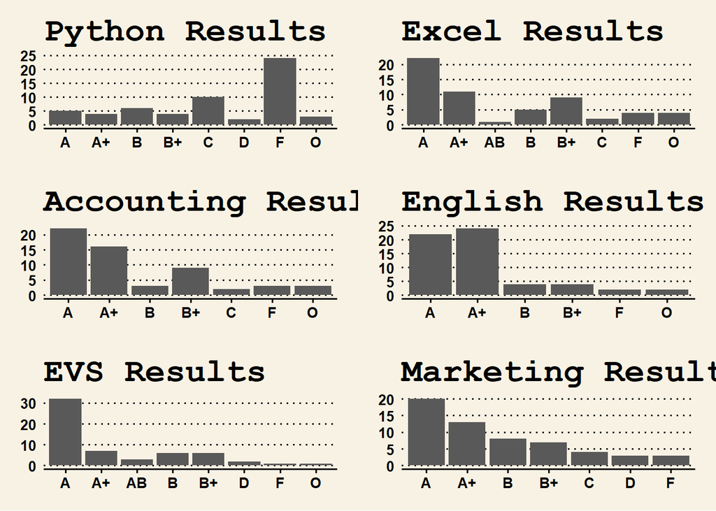

## Python Plot

The failure of the students in this particular subject was the highest in comparison to any subject in the course.

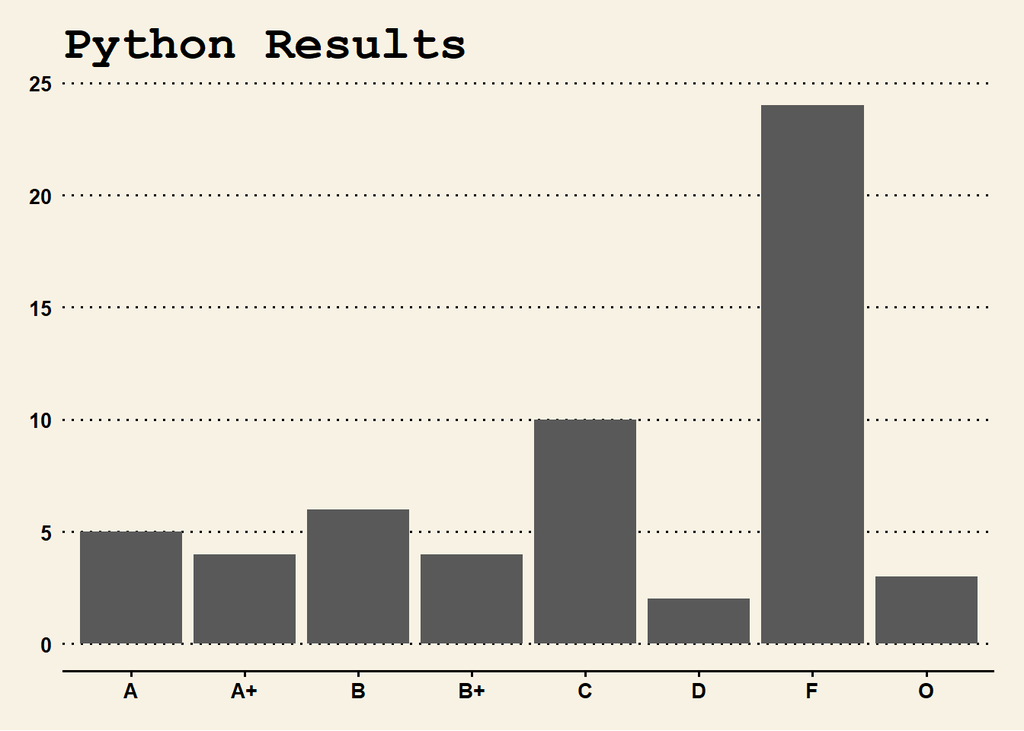

## Excel Plot

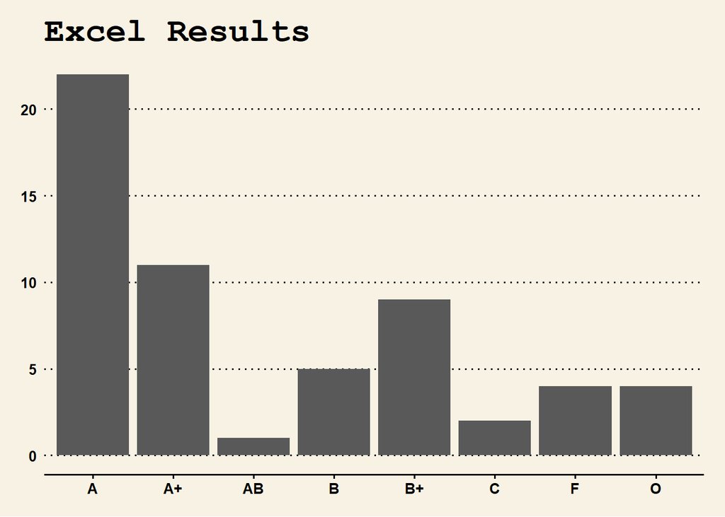

## Marketing Plot

This was the scoring subject for most of the students, More than 90 % of students have passed in this subject with good grades, but a noteworthy notice in this particular subject no one has achieved the highest grade i.e O, which may be the reason of the subjects theoretical nature.

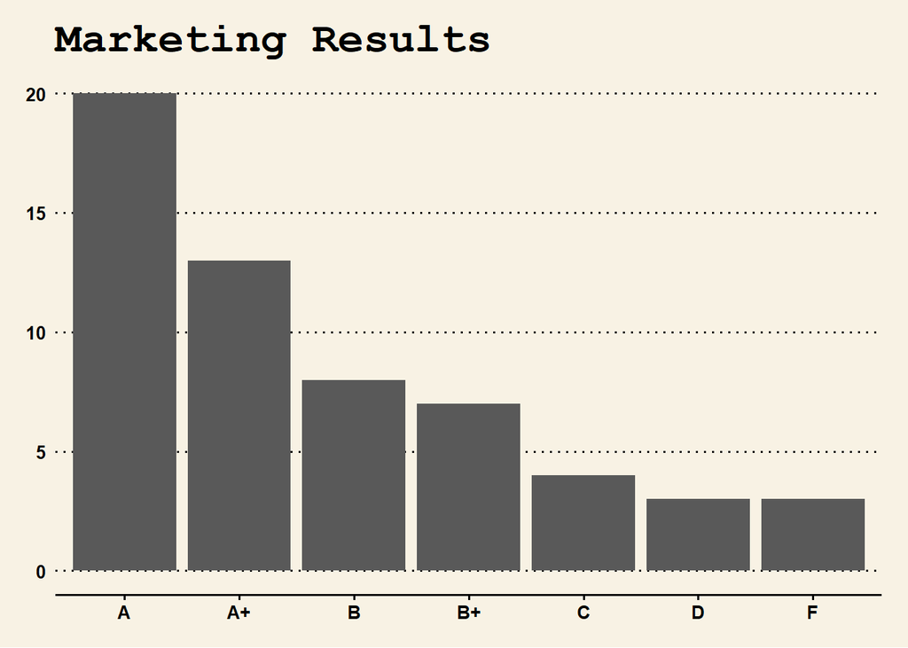

## English Plot

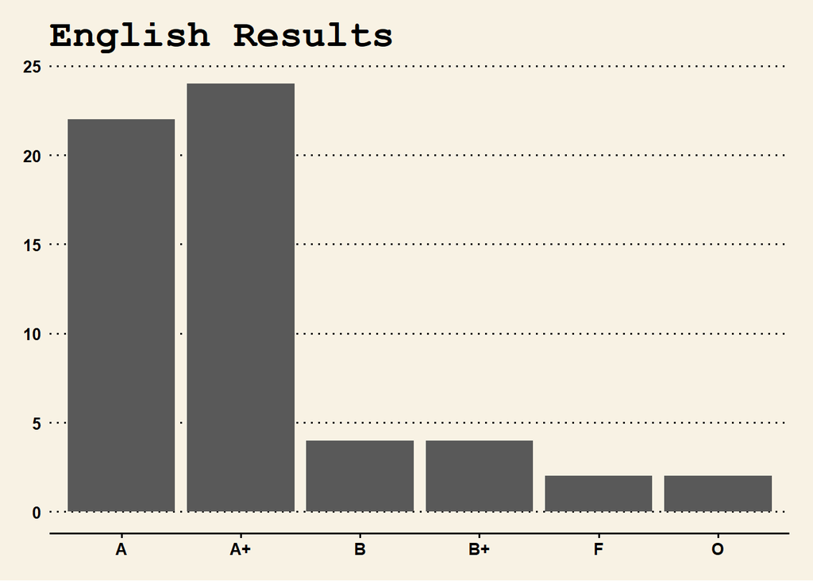

## Accounting Plot

This was a tough subject to tackle with in the class, but most of the students scored pretty good grades in this subject as well.

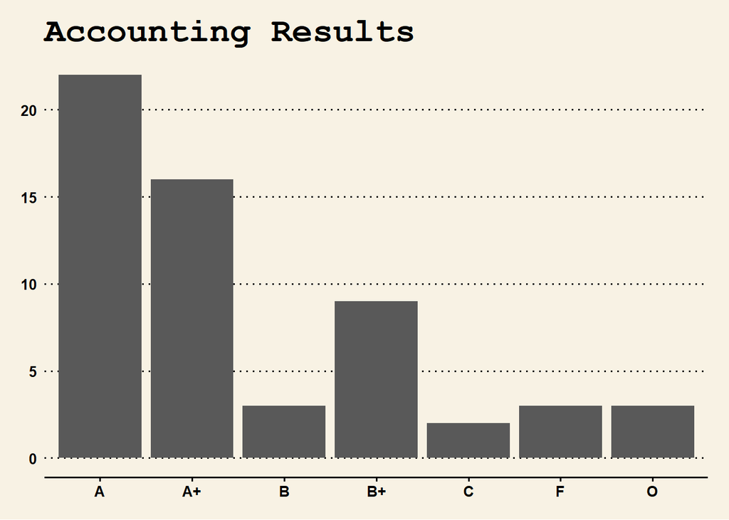

## Environmental Studies Plot

This was the most easiest subject out of all subjects and we can clearly see in the graph that majority of students have scored excellent grades in this subject as well.

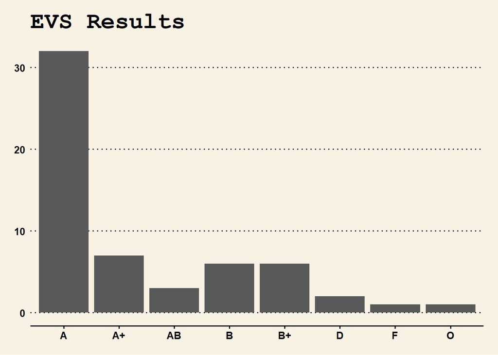

## Passing Students Plot Graph

The following students of 32 have passed the IInd Semester and there results are showcased below:

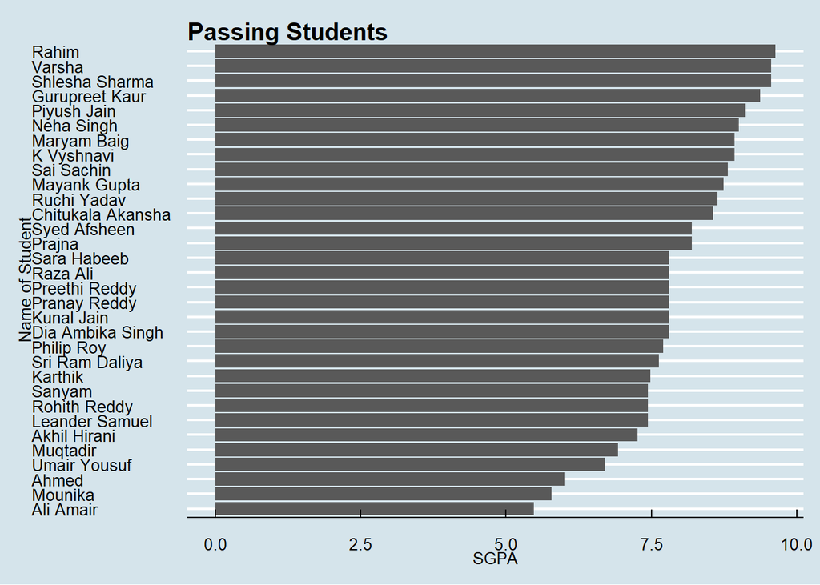

## Top 10 performing students

This semester the top 10 students performed are given below in the table where most of the students had a tough time, these students passed with an exceptional grade. As always Rahim has aced this exams as the top ranker. Congratulations to him!

| Name of Student | Hall Ticket No | Environment | English | Marketing | Accounting | Excel | Python | SGPA | Result |
| --- | --- | --- | --- | --- | --- | --- | --- | --- | --- |
| Rahim | 121423408029 | O | O | A+ | A+ | O | O | 9.63 | Pass |
| Shlesha Sharma | 121423408002 | A+ | A+ | A+ | O | O | O | 9.56 | Pass |
| Varsha | 121423408026 | A+ | O | A+ | A+ | O | O | 9.56 | Pass |
| Gurupreet Kaur | 121423408001 | A+ | A+ | A+ | A+ | B | B+ | 9.37 | Pass |
| Piyush Jain | 121423408006 | A | A+ | A+ | O | A+ | A+ | 9.11 | Pass |
| Neha Singh | 121423408012 | A+ | A+ | A+ | O | A+ | A | 9.00 | Pass |
| K Vyshnavi | 121423408008 | A | A | A+ | A+ | O | A+ | 8.93 | Pass |
| Maryam Baig | 121423408041 | A | A+ | A+ | A+ | A+ | A+ | 8.93 | Pass |
| Sai Sachin | 121423408039 | A+ | A+ | A+ | A | A+ | A+ | 8.81 | Pass |
| Mayank Gupta | 121423408005 | A | A+ | A+ | A+ | A+ | A | 8.74 | Pass |